# R para ciência de dados II: Trabalho conclusão curso

Charles Ferreira de Souza

#### As questões a seguir respondem ao que nos foi proposto no trabalho de conclusão do curso `R para ciência de dados II`, ministrado pela [`Curso-R`](https://curso-r.com/)

#### 1. Qual o mês do ano com o maior número de filmes? E o dia do ano?

##### Na base de dados IMDB o mês do ano com maior número de filmes é out com 8.734 lançados, enquanto o dia com maior número de filmes é 1 com 7.260

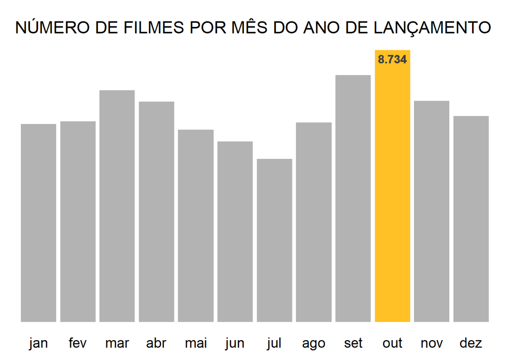

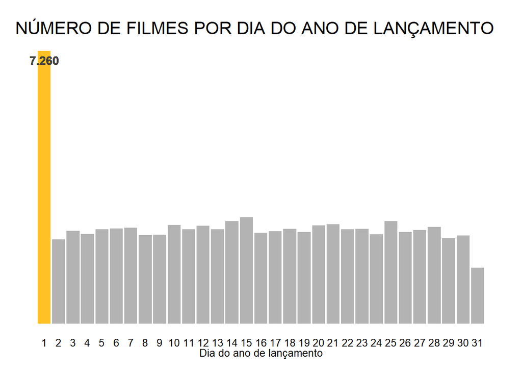

#### 2. Qual o top 5 países com mais filmes na base?

##### Os paises com mais filmes na base são: USA,India,UK,France e Italy. É importante mencionar que existem produções filmadas em mais de um país.

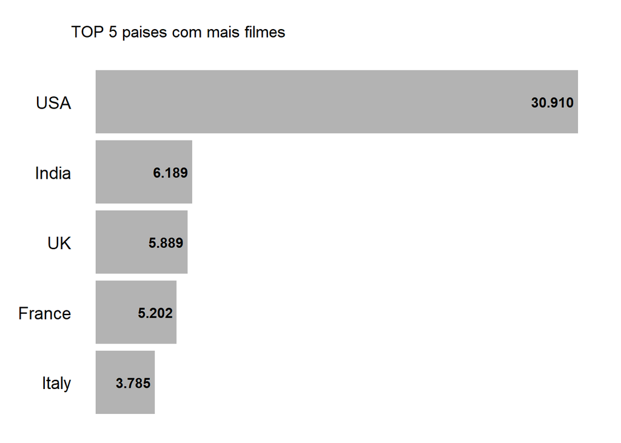

#### 3. Liste todas as moedas que aparecem nas colunas `orcamento` e `receita` da base `imdb_completa`.

##### As moedas que aparecem em “orcamento” são: $,ITL,ROL,SEK,FRF,NOK,GBP,DEM,PTE,FIM,CAD,INR,CHF,ESP,JPY,DKK,NLG,PLN,RUR,AUD,KRW,BEF,XAU,HKD,NZD,CNY,EUR,PYG,ISK,IEP,TRL,HRK,SIT,PHP,HUF,DOP,JMD,CZK,SGD,BRL,BDT,ATS,BND,EGP,THB,GRD,ZAR,NPR,IDR,PKR,MXN,BGL,EEK,YUM,MYR,IRR,CLP,SKK,LTL,TWD,MTL,LVL,COP,ARS,UAH,RON,ALL,NGN,ILS,VEB,VND,TTD,JOD,LKR,GEL,MNT,AZM,AMD e AED.

##### Em “receita” as moedas que aparecem são $,GBP,INR,NPR e PKR

#### 4. Considerando apenas orçamentos e receitas em dólar ($), qual o gênero com maior lucro? E com maior nota média?

##### O gênero com maior lucro é Adventure e o com maior nota média é Documentary. Nas tabelas abaixo são apresentados os cinco principais resultados para lucro e IMDB médio.

Tabela 1: Top 5 gêneros por lucro

| Gênero | Lucro |
| --- | --- |
| Adventure | 144.646.230.045 |
| Animation | 31.497.637.357 |
| Family | 29.593.221.834 |
| Sci-Fi | 23.240.135.418 |
| Fantasy | 1.617.917.510 |

Tabela 2: Top 5 gêneros por nota média IMDB

| Gênero | Nota média IMDB |
| --- | --- |
| Documentary | 7,5 |
| Film-Noir | 7,0 |
| Biography | 6,7 |
| History | 6,5 |
| War | 6,5 |

#### 5. Dentre os filmes na base `imdb_completa`, escolha o seu favorito. Então faça os itens a seguir:

##### Meu filme favorito é Million Dollar Baby de 2004.

#### a) Quem dirigiu o filme? Faça uma ficha dessa pessoa: idade (hoje em dia ou data de falecimento), onde nasceu, quantos filmes já dirigiu, qual o lucro médio dos filmes que dirigiu (considerando apenas valores em dólar) e outras informações que achar interessante (base `imdb_pessoas`).

##### A direção do filme é de Clint Eastwood. Um resumo com as principais informações sobre este diretor estão na tabela abaixo:

| Diretor | Idade | Local nascimento | Número de filmes | Lucro médio dos filmes |
| --- | --- | --- | --- | --- |
| Clint Eastwood | 92 | San Francisco, California, USA | 38 | 61.512.530 |

#### b) Qual a posição desse filme no ranking de notas do IMDB? E no ranking de lucro (considerando apenas valores em dólar)?

##### A posição do filme do ranking de notas do IMDB é 19 e no ranking de lucro é 593

#### c) Em que dia esse filme foi lançado? E dia da semana? Algum outro filme foi lançado no mesmo dia? Quantos anos você tinha nesse dia?

##### O filme foi lançado no dia 18/02/2005, uma sex(Nesta data eu estava com 19 anos de idade). Neste mesmo dia foram lançados outros 15 filmes.

#### d) Faça um gráfico representando a distribuição da nota atribuída a esse filme por idade (base `imdb_avaliacoes`).

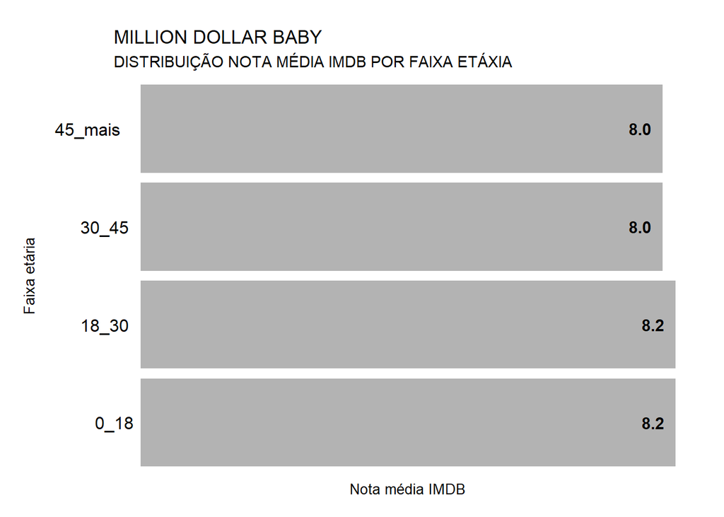